# QVI_RetailAnalytics_task2

Bena

2023-06-15

# Setting up

```r
save.image("QVI_RetailAnalytics_task2.RData")
```

# Load packages

```r
library(data.table)
library(ggplot2)
library(tidyr)
library(tidyverse)
```

# Importing data

```r
data <- fread(paste0("QVI_data.csv"))
# or data2 <- read_csv("QVI_data.csv")
```

# Explore the data

```r
str(data)
```

```
## Classes 'data.table' and 'data.frame':   255510 obs. of  13 variables:
##  $ date            : chr  "10/17/2018" "5/14/2019" "5/20/2019" "8/17/2018" ...
##  $ store_nbr       : int  1 1 1 2 2 4 4 5 7 7 ...
##  $ lylty_card_nbr  : int  1000 1307 1343 2373 2426 4149 4196 5026 7150 7215 ...
##  $ txn_id          : int  1 348 383 974 1038 3333 3539 4525 6900 7176 ...
##  $ product_number  : int  5 66 61 69 108 16 24 42 52 16 ...
##  $ product_name    : chr  "natural chip        compny seasalt" "ccs nacho cheese" "smiths crinkle cut  chips chicken" "smiths chip thinly  s/cream&onion" ...
##  $ product_quantity: int  2 3 2 5 3 1 1 1 2 1 ...
##  $ total_sales     : num  6 6.3 2.9 15 13.8 5.7 3.6 3.9 7.2 5.7 ...
##  $ package_size    : int  175 175 170 175 150 330 210 150 210 330 ...
##  $ brand           : chr  "natural" "ccs" "smiths" "smiths" ...
##  $ unit_cost       : num  3 2.1 1.45 3 4.6 5.7 3.6 3.9 3.6 5.7 ...
##  $ lifestage       : chr  "YOUNG SINGLES/COUPLES" "MIDAGE SINGLES/COUPLES" "MIDAGE SINGLES/COUPLES" "MIDAGE SINGLES/COUPLES" ...
##  $ segment         : chr  "Premium" "Budget" "Budget" "Budget" ...
##  - attr(*, ".internal.selfref")=<externalptr>
```

```r
skimr::skim_without_charts(data)
```

Data summary

| Name | data |
| --- | --- |
| Number of rows | 255510 |
| Number of columns | 13 |
| Key | NULL |
| _______________________ |  |
| Column type frequency: |  |
| character | 5 |
| numeric | 8 |
| ________________________ |  |
| Group variables | None |

**Variable type: character**

| skim_variable | n_missing | complete_rate | min | max | empty | n_unique | whitespace |
| --- | --- | --- | --- | --- | --- | --- | --- |
| date | 0 | 1 | 8 | 10 | 0 | 364 | 0 |
| product_name | 0 | 1 | 12 | 37 | 0 | 111 | 0 |
| brand | 0 | 1 | 3 | 10 | 0 | 20 | 0 |
| lifestage | 0 | 1 | 8 | 22 | 0 | 7 | 0 |
| segment | 0 | 1 | 6 | 10 | 0 | 3 | 0 |

**Variable type: numeric**

| skim_variable | n_missing | complete_rate | mean | sd | p0 | p25 | p50 | p75 | p100 |
| --- | --- | --- | --- | --- | --- | --- | --- | --- | --- |
| store_nbr | 0 | 1 | 135.07 | 76.75 | 1.00 | 70.00 | 130.0 | 203.0 | 272.0 |
| lylty_card_nbr | 0 | 1 | 135537.80 | 80549.38 | 1000.00 | 70030.25 | 130354.0 | 203077.8 | 2373711.0 |
| txn_id | 0 | 1 | 135148.44 | 78103.02 | 1.00 | 67668.25 | 135122.5 | 202627.8 | 2415841.0 |
| product_number | 0 | 1 | 56.45 | 33.41 | 1.00 | 28.00 | 53.0 | 86.0 | 114.0 |
| product_quantity | 0 | 1 | 1.91 | 0.34 | 1.00 | 2.00 | 2.0 | 2.0 | 5.0 |
| total_sales | 0 | 1 | 7.21 | 2.51 | 1.50 | 5.40 | 7.4 | 8.8 | 29.5 |
| package_size | 0 | 1 | 178.14 | 61.37 | 70.00 | 150.00 | 170.0 | 175.0 | 380.0 |
| unit_cost | 0 | 1 | 3.78 | 1.10 | 1.32 | 3.00 | 3.7 | 4.4 | 6.5 |

```r
summary(data)
```

```
##      date             store_nbr     lylty_card_nbr        txn_id
##  Length:255510      Min.   :  1.0   Min.   :   1000   Min.   :      1
##  Class :character   1st Qu.: 70.0   1st Qu.:  70030   1st Qu.:  67668
##  Mode  :character   Median :130.0   Median : 130354   Median : 135123
##                     Mean   :135.1   Mean   : 135538   Mean   : 135148
##                     3rd Qu.:203.0   3rd Qu.: 203078   3rd Qu.: 202628
##                     Max.   :272.0   Max.   :2373711   Max.   :2415841
##  product_number   product_name       product_quantity  total_sales
##  Min.   :  1.00   Length:255510      Min.   :1.000    Min.   : 1.50
##  1st Qu.: 28.00   Class :character   1st Qu.:2.000    1st Qu.: 5.40
##  Median : 53.00   Mode  :character   Median :2.000    Median : 7.40
##  Mean   : 56.45                      Mean   :1.906    Mean   : 7.21
##  3rd Qu.: 86.00                      3rd Qu.:2.000    3rd Qu.: 8.80
##  Max.   :114.00                      Max.   :5.000    Max.   :29.50
##   package_size      brand             unit_cost      lifestage
##  Min.   : 70.0   Length:255510      Min.   :1.320   Length:255510
##  1st Qu.:150.0   Class :character   1st Qu.:3.000   Class :character
##  Median :170.0   Mode  :character   Median :3.700   Mode  :character
##  Mean   :178.1                      Mean   :3.778
##  3rd Qu.:175.0                      3rd Qu.:4.400
##  Max.   :380.0                      Max.   :6.500
##    segment
##  Length:255510
##  Class :character
##  Mode  :character
##
##
##
```

```r
data$date <- as.Date(data$date, format = "%m/%d/%Y")
data$year <- format(as.Date(data$date, format = "%m/%d/%Y"),"%Y")
data$month <- format(as.Date(data$date, format = "%m/%d/%Y"),"%m")
```

```r
data$yearmonth <- format(as.Date(data$date, format = "%m/%d/%Y"),"%Y%m")
```

The client has selected store numbers 77, 86 and 88 as trial stores and wants control stores to be established stores that are operational for the entire observation period. We’ll match trial stores to control stores that are similar to the trial store prior to the trial period of Feb 2019 in terms of :

1. Monthly overall sales revenue
2. Monthly number of customers
3. Monthly number of transactions per customer

```r
measureOverTime <- as.data.table(measureOverTime)
```

Find out stores with observations for all 12 months prior to the trial period

```r
storesWithFullObs <- measureOverTime %>%
  group_by(store_nbr) %>%
  summarise(count = n()) %>%
  filter(count == 12)

storesWithFullObs <-  storesWithFullObs$store_nbr

# storesWithFullObs <- unique(measureOverTime[, .N, store_nbr][N == 12, store_nbr])
```

Filter & retain stores with data for all year prior to the trial period i.e Feb 2019

```r
preTrialMeasures <- measureOverTime %>%
  filter(yearmonth < 201902,
         store_nbr %in% storesWithFullObs)

# preTrialMeasures<-measureOverTime[yearmonth < 201902 & store_nbr %in% storesWithFullObs, ]
```

Find out the correlation between each potential control store and trial store We’ll use a function for this so we don’t have to calculate this for each trial store and control store pair

```r
calculateCorrelation <- function(inputTable, metricCol, storeComparison) {
calcCorrTable = data.table(Store1 = numeric(), Store2 = numeric(), corr_measure = numeric())
storeNumbers <- unique(inputTable[, store_nbr])
for (i in storeNumbers) {
calculatedMeasure = data.table("Store1" = storeComparison, "Store2" = i, "corr_measure" = cor(inputTable[store_nbr == storeComparison, eval(metricCol)], inputTable[store_nbr == i, eval(metricCol)]))
calcCorrTable <- rbind(calcCorrTable, calculatedMeasure)
}
return(calcCorrTable)
}
```

Definition of arguments in the function: - inputTable is a metric table with potential comparison stores - metricCol is the store metric used to calculate correlation on - storeComparison is the store number of the trial store.

Use the function to find the control stores! We’ll select control stores based on how similar monthly total sales and monthly number of customers are to the trial stores.

# Trial Store 77

```r
trial_store77 <- 77
corr_nSales <- calculateCorrelation(preTrialMeasures,quote(totSales),trial_store77)
corr_nCustomers <- calculateCorrelation(preTrialMeasures, quote(nCustomers),trial_store77)
```

Apart from correlation, we can also calculate a standardized metric based on the absolute difference between the trial store’s performance and each control store’s performance. The function for this is:

```r
calculateMagnitudeDistance <- function(inputTable, metricCol, storeComparison){
calcDistTable = data.table(Store1 = numeric(), Store2 = numeric(), yearmonth = numeric(), measure = numeric())
storeNumbers <- unique(inputTable[, store_nbr])
for (i in storeNumbers) {
calculatedMeasure = data.table("Store1" = storeComparison, "Store2" = i, "yearmonth" = inputTable[store_nbr ==storeComparison, yearmonth], "measure" = abs(inputTable[store_nbr == storeComparison, eval(metricCol)]-inputTable[store_nbr == i,eval(metricCol)]))
calcDistTable <- rbind(calcDistTable, calculatedMeasure)
}
#### Standardize the magnitude distance so that the measure ranges from 0 to 1

minMaxDist <- calcDistTable[, .(minDist = min(measure), maxDist = max(measure)), by = c("Store1", "yearmonth")]
distTable <- merge(calcDistTable, minMaxDist, by = c("Store1", "yearmonth"))
distTable[, magnitudeMeasure := 1 - (measure - minDist)/(maxDist - minDist)]
finalDistTable <- distTable[, .(mag_measure = mean(magnitudeMeasure)), by =.(Store1, Store2)]
return(finalDistTable)
}
```

Use the function to calculate magnitude distance

```r
magnitude_nSales <- calculateMagnitudeDistance(preTrialMeasures, quote(totSales), trial_store77)
magnitude_nCustomers <- calculateMagnitudeDistance(preTrialMeasures, quote(nCustomers), trial_store77)
```

Create a combined score composed of correlation and magnitude

```r
score_nSales <- corr_nSales %>%
  full_join(magnitude_nSales, by="Store2","Store1") %>%
  mutate(scoreNsales = corr_measure*0.5 + mag_measure*0.5)
```

```r
score_nSales <- score_nSales %>%
  select(-Store1.y)             #deletes the column which is a duplicate of Store1.x
```

```r
names(score_nSales)[1] <- "Store1"      #renames Store1.x
```

```r
score_nCustomers <- corr_nCustomers %>%
  full_join(magnitude_nCustomers, by="Store2") %>%
  mutate(scoreNcustomers = corr_measure*0.5 + mag_measure*0.5)
```

```r
score_nCustomers <- score_nCustomers %>%
  select(-Store1.y)
```

```r
names(score_nCustomers)[1] <- "Store1"
```

```r
score_Control <- score_nSales %>%
  full_join(score_nCustomers, by = "Store2") %>%
  mutate(finalScore = scoreNsales * 0.5 + scoreNcustomers * 0.5) %>%
  arrange(-finalScore)

score_Control <- score_Control %>%
  select(-Store1.y)

colnames(score_Control)[1] <- "Store1"         #renames from Store1.x

# score_Control <- merge(score_nSales, score_nCustomers, by = c("Store1", "Store2"))
# score_Control[,finalControlScore := scoreNsales * 0.5 + scoreNcustomers * 0.5]
```

The control store is one with the highest `finalscore` closest to 1, ranks second after store_nbr 77

```r
control_store77 <- as.numeric(score_Control[2,2])
control_store77
```

```
## [1] 233
```

```r
# control_store77 <- score_Control[Store1 == trial_store77,][order(-finalControlScore)][2, Store2]
```

Visual check if the totSales & nCustomers are indeed similar in the period before the trial.

```r
measureOverTimeSales <- measureOverTime
measureOverTimeSales$yearmonth <- as.numeric(measureOverTimeSales$yearmonth)

pastSales <- measureOverTimeSales %>%
  mutate(store_type = ifelse(store_nbr == 77, "trial store",
                             ifelse(store_nbr == 233,"control store","other store")))

pastSales <- pastSales[,totSales := mean(totSales), by = c("yearmonth","store_type")]

pastSales$yearmonth <- as.numeric(pastSales$yearmonth)

pastSales <- pastSales %>%
  mutate (TransactionMonth = as.Date(paste(yearmonth %/% 100, yearmonth %% 100, 1, sep = "‐"), "%Y‐%m‐%d"))%>%
  filter(yearmonth < 201902)

# pastSales <- measureOverTimeSales[, Store_type := ifelse(store_nbr == trial_store77, "trial store",
# ifelse(store_nbr == 233, "control store", "Other stores"))][, totSales := mean(totSales), by = c("yearmonth","Store_type")][, TransactionMonth :=as.Date(paste(yearmonth %/% 100, yearmonth %% 100, 1, sep = "‐"), "%Y‐%m‐%d")][yearmonth < 201903 , ]
```

calculating the total column

```r
# means <- pastSales2 %>%   to revisit, how to merge this with pastsales2, without summarizing
#   group_by(yearmonth, store_type) %>%
#   summarise(
#     mean_calc = mean(totSales)
#   )
```

Visual check based on sales

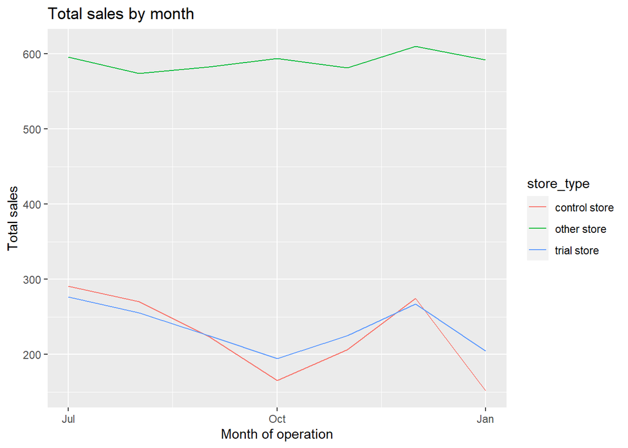

```r
ggplot(pastSales, aes(TransactionMonth, totSales, color = store_type)) +
geom_line() +
labs(x = "Month of operation", y = "Total sales", title = "Total sales by month")
```

```r
# measureOverTimeCust <- measureOverTime
#
# measureOverTimeCust <- as.data.table(measureOverTimeCust)
#
# measureOverTimeCust$yearmonth <- as.numeric(measureOverTimeCust$yearmonth)
#
# pastCustomers <- measureOverTimeCust[, store_type := ifelse(store_nbr == 77, "Trial", ifelse(store_nbr == 233, "Control", "Other stores"))][, numberCustomers :=mean(nCustomers), by = c("yearmonth", "store_type")][, TransactionMonth :=as.Date(paste(yearmonth %/% 100, yearmonth %% 100, 1, sep = "‐"), "%Y‐%m‐%d")][yearmonth < 201902 , ]
```

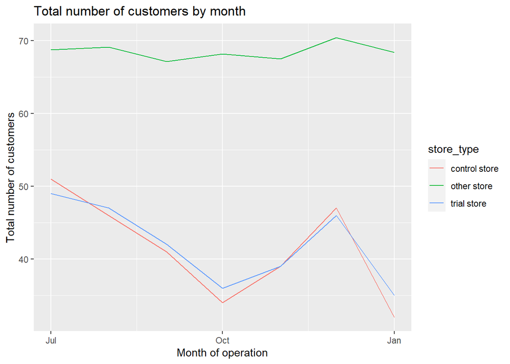

```r
ggplot(pastCustomers, aes(TransactionMonth, numberCustomers, color = store_type)) +
geom_line() +
labs(x = "Month of operation", y = "Total number of customers", title = "Total number of customers by month")
```

### Assessment of trial

*Sales assessment*

We’ll start with scaling the control store’s sales to a similar level to control for any differences between the two stores outside of the trial period.

Scale pre‐trial control store sales to match pre‐trial trial store sales

```r
scalingFactorForControlSales <- preTrialMeasures[store_nbr == 77 & yearmonth < 201902, sum(totSales)]/preTrialMeasures[store_nbr == 233 & yearmonth < 201902, sum(totSales)]
```

```r
measureOverTimeSales2 <- measureOverTime

scaledControlSales <- measureOverTimeSales2 %>%
  filter(store_nbr == control_store77) %>%
  mutate(controlSales = totSales * scalingFactorForControlSales)

# scaledControlSales <- measureOverTimeSales2[store_nbr == control_store77, ][ , controlSales := totSales * scalingFactorForControlSales]
```

Calculate the percentage difference between scaled control sales and trial sales

```r
scaledControlSales$yearmonth <- as.numeric(scaledControlSales$yearmonth)
measureOverTimeSales2$yearmonth <- as.numeric(measureOverTimeSales2$yearmonth)

measureOverTimeSales2 <- measureOverTimeSales2 %>%
  filter(store_nbr == trial_store77)

percentageDiff <- scaledControlSales %>%
  left_join(measureOverTimeSales2, by = "yearmonth")

percentageDiff <- percentageDiff %>%
  select(yearmonth, controlSales, totSales.y) %>%
  mutate(percentageDiff = abs(controlSales-totSales.y)/controlSales)

# percentageDiff <- merge(scaledControlSales[, c("yearmonth", "controlSales")],
# measureOverTimeSales2[store_nbr == trial_store77, c("totSales","yearmonth")],
# by = "yearmonth")[,percentageDiff := abs(controlSales-totSales)/controlSales]
```

Checking if the difference is significant Our null hypothesis is that the trial period is the same as the pre‐trial period,

Standard deviation based on the scaled percentage difference in the pre‐trial period is calculated using:

```r
stdDev <- sd(percentageDiff[yearmonth < 201902 , percentageDiff])
```

There are 7 months in the pre-trial period, thus N=7 Degrees of freedom is calculated using N-1 i.e. 7 - 1 = 6

```r
degreesFreedom <- 7-1
```

```r
percentageDiff$yearmonth <- as.numeric(percentageDiff$yearmonth)

tValues <- percentageDiff %>%
  filter(yearmonth >= 201902 & yearmonth <=201904) %>%
  mutate(
    t_Value = (percentageDiff-0)/stdDev,
    transactionMonth = as.Date(paste(yearmonth %/% 100,yearmonth %% 100, 1, sep = "‐"), "%Y‐%m‐%d")
    )

# percentageDiff[, tValue := (percentageDiff - 0)/stdDev][, TransactionMonth := as.Date(paste(yearmonth %/% 100,yearmonth %% 100, 1, sep = "‐"), "%Y‐%m‐%d")
# ][yearmonth >= 201902 & yearmonth <=201904, .(TransactionMonth,tValue)]
```

Find the t-score for the 95th percentile

```r
qt(0.95, df=degreesFreedom)
```

```
## [1] 1.94318
```

We can also check visually

```r
measureOverTime$yearmonth <- as.numeric(measureOverTime$yearmonth)

pastSales_fullyear <- measureOverTime %>%
  mutate(store_type=ifelse(store_nbr == trial_store77, "trial store",
                           ifelse(store_nbr == control_store77, "control store", "other stores")))

pastSales_fullyear <- pastSales_fullyear[, totSales := mean(totSales), by = c("yearmonth", "store_type")]

pastSales_fullyear <- pastSales_fullyear %>%
  mutate (TransactionMonth = as.Date(paste(yearmonth %/% 100, yearmonth %% 100, 1, sep = "‐"), "%Y‐%m‐%d"))%>%
  filter(store_type  %in% c("trial store", "control store"))

# pastSales_fullyear <- measureOverTime[, store_type := ifelse(store_nbr == trial_store77, "trial store",
# ifelse(store_nbr == control_store77, "control store", "other stores"))][, totSales := mean(totSales), by = c("yearmonth", "store_type")][, TransactionMonth := as.Date(paste(yearmonth %/% 100, yearmonth %% 100, 1, sep = "‐"), "%Y‐%m‐%d")][store_type %in% c("trial store", "control store"), ]
```

Control store 95th percentile

```r
pastSales_Controls95 <- pastSales_fullyear %>%
  filter(store_type == "control store") %>%
  mutate(
    totSales = totSales * (1 + stdDev * 2),
    store_type = "Control 95th % confidence interval"
  )

# pastSales_Controls95 <- pastSales_fullyear[store_type == "control store",][, totSales := totSales * (1 + stdDev * 2)][, store_type := "Control 95th % confidence interval"]
```

Control store 5th percentile

```r
pastSales_Controls5 <- pastSales_fullyear %>%
  filter(store_type == "control store") %>%
  mutate(
    totSales = totSales * (1 - stdDev * 2),
    store_type = "Control 5th % confidence interval"
  )

# pastSales_Controls5 <- pastSales_fullyear[store_type == "control store",][, totSales := totSales * (1 - stdDev * 2)][, store_type := "Control 5th % confidence interval"]
```

Combine the data tables for easier visualization

```r
trialAssessment <- rbind(pastSales_fullyear, pastSales_Controls95, pastSales_Controls5)
```

Visualization for trial Assessment

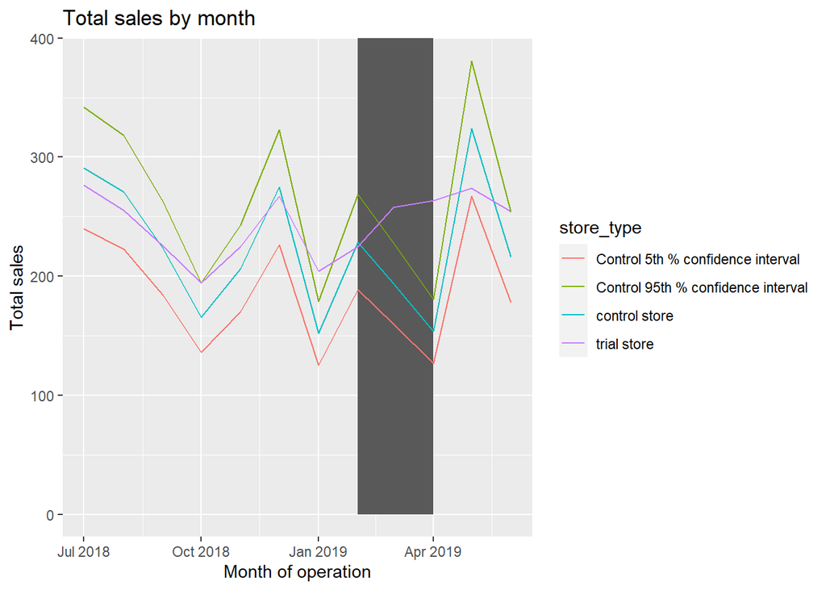

```r
ggplot(trialAssessment, aes(TransactionMonth, totSales, color = store_type)) +
geom_rect(data = trialAssessment[yearmonth >= 201902 & yearmonth <= 201904 ,],
aes(xmin = min(TransactionMonth), xmax = max(TransactionMonth), ymin = 0 ,
ymax = Inf, color = NULL), show.legend = FALSE) +
geom_line() +
labs(x = "Month of operation", y = "Total sales", title = "Total sales by month")
```

```r
# graph1 <- trialAssessment %>%
#   ggplot(aes(x=TransactionMonth, y=totSales, color=store_type)) +
#   geom_rect(data = trialAssessment[ yearmonth < 201905 & yearmonth > 201901 ,], aes(xmin = min(TransactionMonth), xmax = max(TransactionMonth), ymin = 0 ,ymax = Inf, color = NULL)) +
#   geom_line() +
#   labs(x = "Month of operation", y = "Total sales", title = "Total sales by month")
```

*Customer assessment*

Scale pre‐trial control store customers to match pre‐trial trial store customers

```r
scalingFactorForControlCust <- preTrialMeasures[store_nbr == 77 &
yearmonth < 201902, sum(nCustomers)]/preTrialMeasures[store_nbr == 233 & yearmonth < 201902, sum(nCustomers)]
```

```r
measureOverTimeCust2 <- measureOverTime

scaledControlCustomers <- measureOverTimeCust2 %>%
  filter(store_nbr==233) %>%
  mutate(controlCustomers = nCustomers * scalingFactorForControlCust)

# scaledControlCustomers <- measureOverTimeCust2[store_nbr == 233,][ , controlCustomers := nCustomers * scalingFactorForControlCust][, Store_type := ifelse(store_nbr == 77, "Trial",ifelse(store_nbr == 233, "Control", "Other stores"))]
```

Calculate the percentage difference

```r
percentageDiff_cust <- measureOverTimeCust2 %>%
  filter(store_nbr == 77) %>%
  select(yearmonth, nCustomers)

percentageDiff_cust <- scaledControlCustomers %>%
  select(yearmonth, controlCustomers) %>%
  left_join(percentageDiff_cust, by = "yearmonth") %>%
  mutate(percentageDiff = abs(controlCustomers - nCustomers)/controlCustomers)

# percentageDiff_cust <- merge(scaledControlCustomers[, c("yearmonth", "controlCustomers")],
# measureOverTimeCust2[store_nbr == 77, c("nCustomers", "yearmonth")],
# by = "yearmonth")[, percentageDiff := abs(controlCustomers - nCustomers)/controlCustomers]
```

Checking if the difference is significant

As our null hypothesis is that the trial period is the same as the pre‐trial period, let’s take the standard deviation based on the scaled percentage difference in the pre‐trial period

```r
stdDev_cust <- sd(percentageDiff_cust[yearmonth < 201902, percentageDiff])

stdDev_cust
```

```
## [1] 0.02616946
```

number of customers in trial and control stores

```r
pastCustomers <- measureOverTimeCust2 %>%
  mutate(store_type = ifelse(store_nbr == 77, "trial store",
                             ifelse(store_nbr == 233,"control store","other store")))

pastCustomers <- as.data.table(pastCustomers)

pastCustomers <- pastCustomers[,numberCustomers := mean(nCustomers), by = c("yearmonth","store_type")]

pastCustomers <- pastCustomers %>%
  filter(store_type == "trial store"|store_type == "control store")

pastCustomers <- pastCustomers %>%
  mutate (TransactionMonth = as.Date(paste(yearmonth %/% 100, yearmonth %% 100, 1, sep = "‐"), "%Y‐%m‐%d"))%>%
  filter(store_type  %in% c("trial store", "control store"))

# pastCustomers <- measureOverTimeCust2[, nCusts := mean(nCustomers), by = c("yearmonth", "store_type")][store_type %in% c("Trial", "Control"), ]
```

Control store 95th percentile

```r
pastCustomers_Controls95 <- pastCustomers %>%
  filter(store_type == "control store") %>%
  mutate(
     nCustomers = nCustomers * (1 + stdDev * 2),
     store_type = "Control 95th % confidence interval"
  )
```

Control store 5th percentile

```r
pastCustomers_Controls5 <- pastCustomers %>%
  filter(store_type == "control store") %>%
  mutate(
    nCustomers = nCustomers * (1 - stdDev * 2),
    store_type = "Control 5th % confidence interval"
  )
```

Combine the data tables

```r
trialAssessment_cust <- rbind(pastCustomers, pastCustomers_Controls95, pastCustomers_Controls5)
```

Visualization for trialAssessment_cust

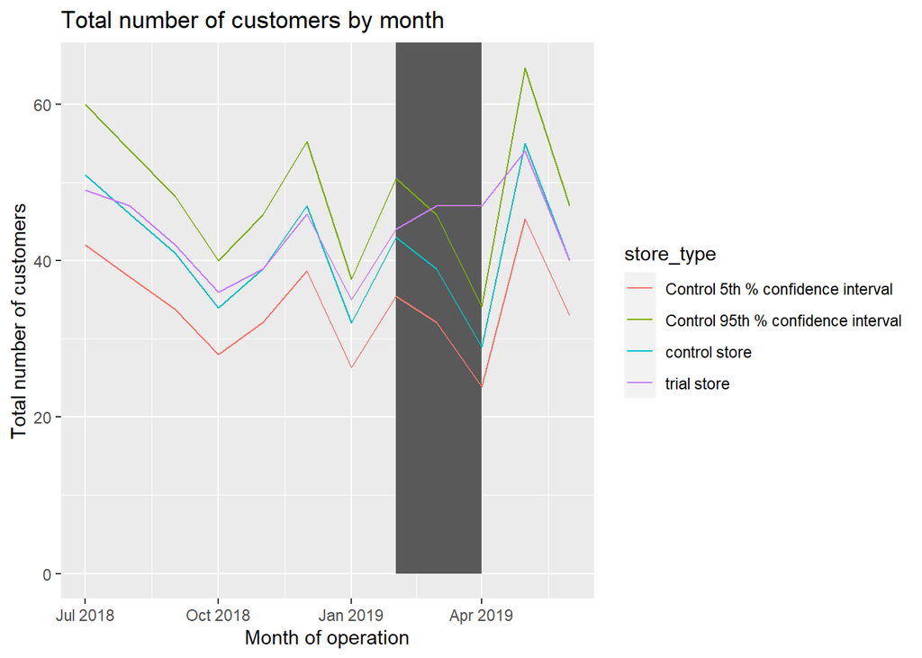

```r
ggplot(trialAssessment_cust, aes(TransactionMonth, nCustomers, color = store_type)) +
geom_rect(data = trialAssessment_cust[yearmonth >= 201902 & yearmonth <= 201904,],
aes(xmin = min(TransactionMonth), xmax = max(TransactionMonth), ymin = 0 ,
ymax = Inf, color = NULL), show.legend = FALSE) +
geom_line() +
labs(x = "Month of operation", y = "Total number of customers", title = "Total number of customers by month")
```

The performance for trial store is significantly different for 2/3 months of the trial period i.e March & April it lies outside the 5% & 95% confidence interval of the control store.

# Trial Store 86

Use the earlier defined correlation function to find correlations between store_nbr 86 & other stores

```r
trial_store86 <- 86
corr_nSales86 <- calculateCorrelation(preTrialMeasures,quote(totSales),trial_store86)
corr_nCustomers86 <- calculateCorrelation(preTrialMeasures, quote(nCustomers),trial_store86)
```

Calculate magnitude distance between sales & number of customers for store 86 & other stores

```r
magnitude_nSales86 <- calculateMagnitudeDistance(preTrialMeasures, quote(totSales), trial_store86)
magnitude_nCustomers86 <- calculateMagnitudeDistance(preTrialMeasures, quote(nCustomers), trial_store86)
```

Create a combined score for correlation & magnitude distance for the two metrics i.e totSales & nCustomers 0.5 is the weight attached to correlation, thus the weight attached to mag_measure is 1-0.5

```r
score_nSales86 <- corr_nSales86 %>%
  full_join(magnitude_nSales86, by = "Store2") %>%
  mutate(scoreNsales = corr_measure*0.5 + mag_measure*0.5) %>%
  select(-Store1.y) %>%
  rename(Store1 = Store1.x)
```

```r
score_nCustomers86 <- corr_nCustomers86 %>%
  full_join(magnitude_nCustomers86, by = "Store2") %>%
  select(-Store1.y) %>%
  rename(Store1 = Store1.x) %>%
  mutate(scoreNcustomers = corr_measure*0.5 + mag_measure*0.5)
```

Combine score_nSales86 & score_nCustomers86 i.e scores for the 2 metrics

```r
score_Control86 <- score_nSales86 %>%
  full_join(score_nCustomers86, by = "Store2") %>%
  mutate(finalScore = scoreNsales * 0.5 + scoreNcustomers * 0.5) %>%
  arrange(-finalScore) %>%
  select(-Store1.y) %>%
  rename(Store1 = Store1.x)
```

Select the control store, it should be next after the trial store(finalScore=1) with a score close to 1

```r
control_store86 <- score_Control86[2,Store2]
control_store86
```

```
## [1] 155
```

store_nbr 155 is most likely the control store for store_nbr 86 We’ll need to verify that the totSales & nCustomers have similar trends before the trial period

```r
measureOverTimeSales86 <- measureOverTime86

measureOverTimeSales86$yearmonth <- as.numeric(measureOverTimeSales86$yearmonth)

pastSales86 <- measureOverTimeSales86 %>%
  mutate(store_type = ifelse(store_nbr==86,"trial store",
                             ifelse(store_nbr==155,"control store","other store"))) %>%
  mutate(TransactionMonth = as.Date(paste(yearmonth %/% 100, yearmonth %% 100, 1, sep = "‐"), "%Y‐%m‐%d"))

pastSales86 <- pastSales86[,totSales := mean(totSales), by = c("yearmonth","store_type")]

pastSales86 <- pastSales86 %>%
  filter(yearmonth < 201902)
```

Visual check for sales

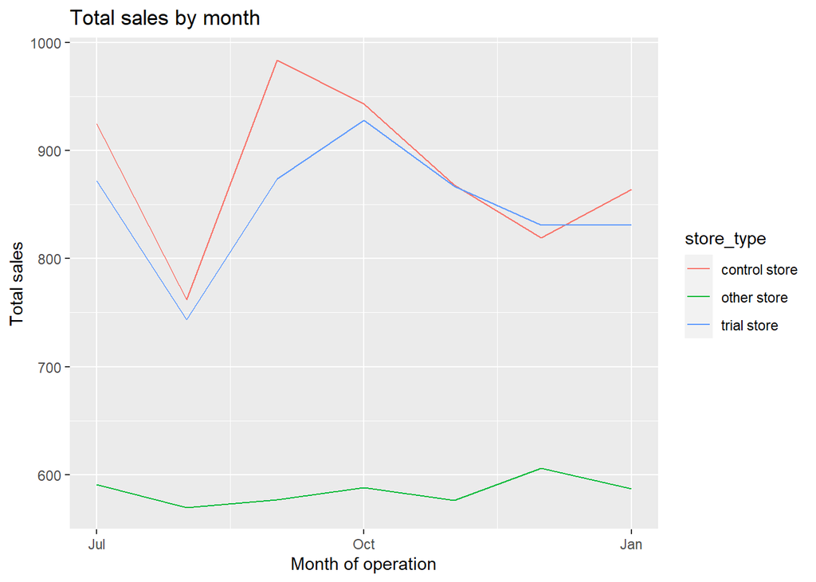

```r
pastSales86 %>%
  ggplot(aes(x=TransactionMonth, y=totSales, color=store_type)) +
  geom_line() +
  labs(title="Total sales by month", x="Month of operation", y="Total sales")
```

We can see that the sales for the control & trial stores have the same trend

Visual check of the nCustomers trend

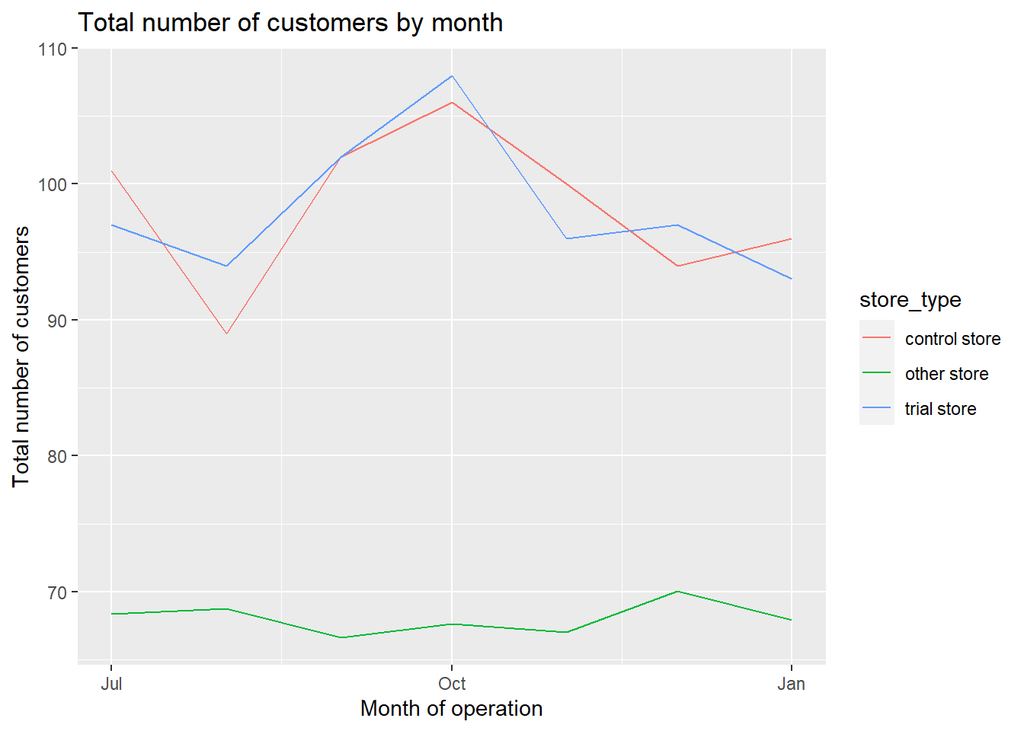

```r
pastCustomers86 %>%
  ggplot(aes(x=TransactionMonth, y=numberCustomers, color=store_type)) +
  geom_line() +
  labs(title="Total number of customers by month", x="Month of operation", y="Total number of customers")
```

The trend for number of customers is also similar for the control & trial stores

### Assessment of trial

*Sales assessment*

Scale control sales to match pre-trial sales

```r
scalingFactorForControlSales86 <- preTrialMeasures[store_nbr == 86 & yearmonth < 201902, sum(totSales)]/preTrialMeasures[store_nbr == 155 & yearmonth < 201902, sum(totSales)]
```

Apply the scalingFactor

```r
measureOverTimeSales86 <- measureOverTime86

scaledControlSales86 <- measureOverTimeSales86 %>%
  filter(store_nbr == control_store86) %>%
  mutate(controlSales = totSales * scalingFactorForControlSales86)
```

Calculate the percentage difference between scaled control sales and trial sales

```r
measureOverTimeSales86_2 <- measureOverTimeSales86 %>%
  filter(store_nbr == trial_store86)

percentageDiff86 <- scaledControlSales86 %>%
  left_join(measureOverTimeSales86_2, by = "yearmonth") %>%
  select(yearmonth, controlSales, totSales.y) %>%
  mutate(percentageDiff = abs(controlSales-totSales.y)/controlSales)
```

Checking if the difference is significant Our null hypothesis is that the trial period is the same as the pre‐trial period

calculate standard deviation based on the scaled percentage difference in the pre‐trial period using:

```r
stdDev86 <- sd(percentageDiff86[yearmonth < 201902 , percentageDiff])
```

Trial & control store sales for full year

```r
measureOverTime86$yearmonth <- as.numeric(measureOverTime86$yearmonth)

pastSales_fullyear86 <- measureOverTime86 %>%
  mutate(store_type=ifelse(store_nbr == trial_store86, "trial store",
                           ifelse(store_nbr == control_store86, "control store", "other stores"))) %>%
   mutate (TransactionMonth = as.Date(paste(yearmonth %/% 100, yearmonth %% 100, 1, sep = "‐"), "%Y‐%m‐%d"))

pastSales_fullyear86 <- pastSales_fullyear86[, totSales := mean(totSales), by = c("yearmonth", "store_type")]

pastSales_fullyear86 <- pastSales_fullyear86 %>%
  filter(store_type  %in% c("trial store", "control store"))
```

Control store 95th percentile

```r
pastSales86_Controls95 <- pastSales_fullyear86 %>%
  filter(store_type == "control store") %>%
  mutate(
    totSales = totSales * (1 + stdDev86 * 2),
    store_type = "Control 95th % confidence interval"
  )
```

Control store 5th percentile

```r
pastSales86_Controls5 <- pastSales_fullyear86 %>%
  filter(store_type == "control store") %>%
  mutate(
    totSales = totSales * (1 - stdDev86 * 2),
    store_type = "Control 5th % confidence interval"
  )
```

Combine the 3 data tables for easy visualization

```r
trialAssessment86 <- rbind(pastSales_fullyear86, pastSales86_Controls95, pastSales86_Controls5)
```

Visualize

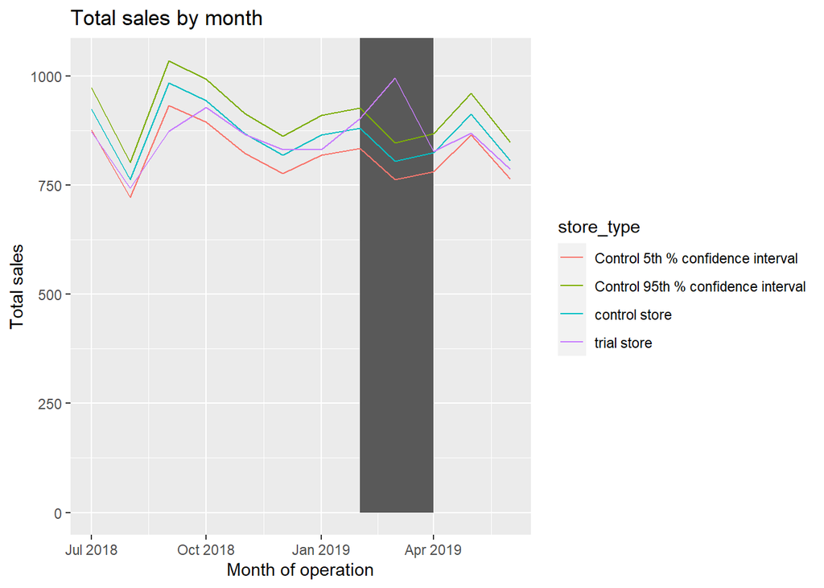

```r
ggplot(trialAssessment86, aes(TransactionMonth, totSales, color = store_type)) +
geom_rect(data = trialAssessment86[yearmonth >= 201902 & yearmonth <= 201904 ,],
aes(xmin = min(TransactionMonth), xmax = max(TransactionMonth), ymin = 0 ,
ymax = Inf, color = NULL), show.legend = FALSE) +
geom_line() +
labs(x = "Month of operation", y = "Total sales", title = "Total sales by month")
```

*Customer assessment*

Scale pre‐trial control store customers to match pre‐trial trial store customers

```r
scalingFactorForControlCust86 <- preTrialMeasures[store_nbr == 86 &
yearmonth < 201902, sum(nCustomers)]/preTrialMeasures[store_nbr == 155 & yearmonth < 201902, sum(nCustomers)]
```

Apply the scalingFactor

```r
measureOverTimeCust86_2 <-measureOverTime86

scaledControlCust86 <- measureOverTimeCust86_2 %>%
 filter(store_nbr == control_store86) %>%
  mutate(controlCustomers = nCustomers * scalingFactorForControlCust86)
```

Calculate the percentage difference

```r
percentageDiff_cust86 <- measureOverTimeCust86_2 %>%
  filter(store_nbr == 86) %>%
  select(yearmonth, nCustomers)

percentageDiff_cust86 <- scaledControlCust86 %>%
  select(yearmonth, controlCustomers) %>%
  left_join(percentageDiff_cust86, by = "yearmonth") %>%
  mutate(percentageDiff = abs(controlCustomers - nCustomers)/controlCustomers)
```

Checking if the difference is significant

```r
stdDev_cust86 <- sd(percentageDiff_cust86[yearmonth < 201902, percentageDiff])
```

Control store 95th percentile

```r
pastCustomers86_Controls95 <- pastCustomers_fullyear86 %>%
  filter(store_type == "control store") %>%
  mutate(
     nCustomers = nCustomers * (1 + stdDev86 * 2),
     store_type = "Control 95"
  )
```

Control store 5th percentile

```r
pastCustomers86_Controls5 <- pastCustomers_fullyear86 %>%
  filter(store_type == "control store") %>%
  mutate(
    nCustomers = nCustomers * (1 - stdDev86 * 2),
    store_type = "Control 5"
  )
```

Combine the data sets

```r
trialAssessment_cust86 <- rbind(pastCustomers_fullyear86, pastCustomers86_Controls95, pastCustomers86_Controls5)
```

Visualization of trialAssessment_cust86

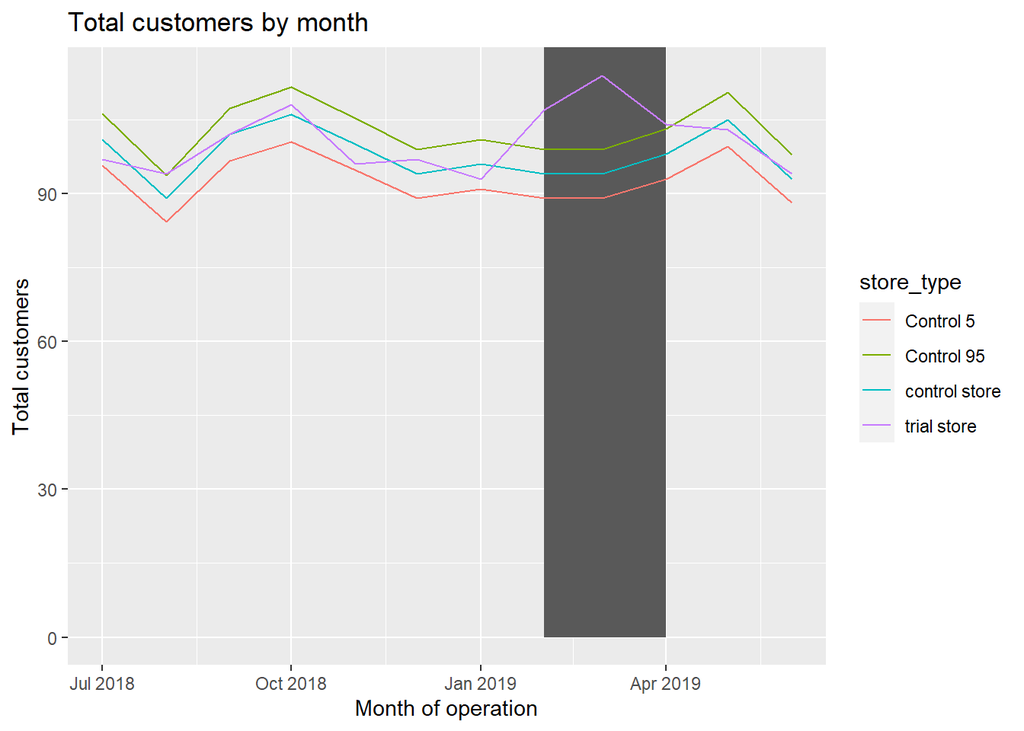

```r
ggplot(trialAssessment_cust86, aes(TransactionMonth, nCustomers, color = store_type)) +
geom_rect(data = trialAssessment_cust86[yearmonth >= 201902 & yearmonth <= 201904 ,],
aes(xmin = min(TransactionMonth), xmax = max(TransactionMonth), ymin = 0 ,
ymax = Inf, color = NULL), show.legend = FALSE) +
geom_line() +
labs(x = "Month of operation", y = "Total customers", title = "Total customers by month")
```

The number of customers is significantly higher in 3/3 months of the trial period.

But since this was not the case with total Sales for that period, we may want to find out whether there were special offers that might have impacted revenue.

# Trial Store 88

```r
trial_store88 <- 88
corr_nSales88 <- calculateCorrelation(preTrialMeasures, quote(totSales), trial_store88)
corr_nCustomers88 <- calculateCorrelation(preTrialMeasures, quote(nCustomers), trial_store88)
```

```r
magnitude_nSales88 <- calculateMagnitudeDistance(preTrialMeasures, quote(totSales), trial_store88)
magnitude_nCustomers88 <- calculateMagnitudeDistance(preTrialMeasures, quote(nCustomers), trial_store88)
```

Create a combined score for correlation & magnitude distance for the two metrics i.e totSales & nCustomers

```r
score_nSales88 <- corr_nSales88 %>%
  full_join(magnitude_nSales88, by = "Store2") %>%
  mutate(scoreNsales = corr_measure*0.5 + mag_measure*0.5) %>%
  select(-Store1.y) %>%
  rename(Store1 = Store1.x)
```

```r
score_nCustomers88 <- corr_nCustomers88 %>%
  full_join(magnitude_nCustomers88, by = "Store2") %>%
  mutate(scoreNcustomers = corr_measure*0.5 + mag_measure*0.5) %>%
  select(-Store1.y) %>%
  rename(Store1 = Store1.x)
```

```r
score_Control88 <- score_nSales88 %>%
  full_join(score_nCustomers88, by = "Store2") %>%
  mutate(finalScore = scoreNsales * 0.5 + scoreNcustomers * 0.5) %>%
  select(-Store1.y) %>%
  rename(Store1 = Store1.x) %>%
  arrange(-finalScore)
```

Select the control store

```r
control_store88 <- score_Control88[2,Store2]
control_store88
```

```
## [1] 237
```

store_nbr 237 is most likely the control store for store_nbr 88

We’ll need to verify that the totSales & nCustomers have similar trends before the trial period.

```r
measureOverTime88 <- as.data.table(measureOverTime88)
```

```r
measureOverTime88$yearmonth <- as.numeric(measureOverTime88$yearmonth)

pastSales88 <- measureOverTime88 %>%
  mutate(store_type = ifelse(store_nbr==88,"trial store",
                             ifelse(store_nbr==237,"control store","other store"))) %>%
  mutate(TransactionMonth = as.Date(paste(yearmonth %/% 100, yearmonth %% 100, 1, sep = "‐"), "%Y‐%m‐%d"))

pastSales88 <- pastSales88[,totSales := mean(totSales), by = c("yearmonth","store_type")]

pastSales88 <- pastSales88 %>%
  filter(yearmonth < 201902)
```

Visual check for sales

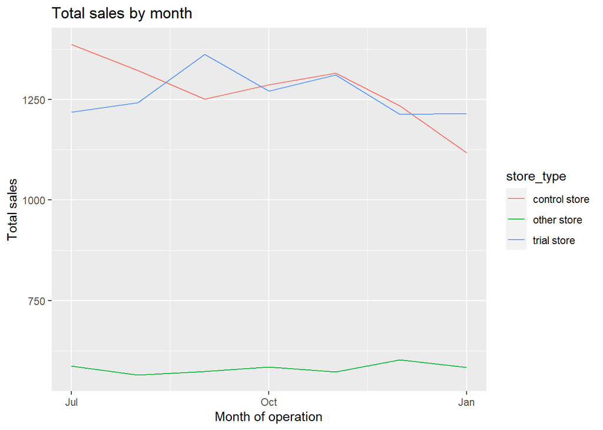

```r
pastSales88 %>%
  ggplot(aes(x=TransactionMonth, y=totSales, color=store_type)) +
  geom_line() +
  labs(title="Total sales by month", x="Month of operation", y="Total sales")
```

The trial & control stores have a similar trend for most of the months

Visual check of the nCustomers trend

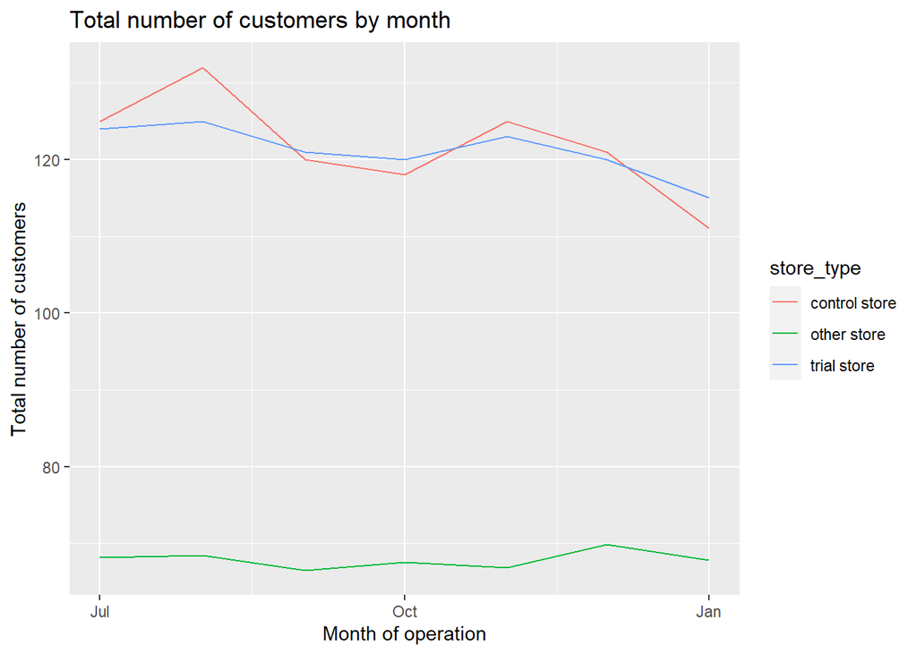

```r
pastCustomers88 %>%
  ggplot(aes(x=TransactionMonth, y=numberCustomers, color=store_type)) +
  geom_line() +
  labs(title="Total number of customers by month", x="Month of operation", y="Total number of customers")
```

The trend for number of customers is similar for both trial & control stores

### Assessment of trial

*Sales assessment*

Scale control sales to match pre-trial sales

```r
scalingFactorForControlSales88 <- preTrialMeasures[store_nbr == 88 & yearmonth < 201902, sum(totSales)]/preTrialMeasures[store_nbr == 237 & yearmonth < 201902, sum(totSales)]
```

Apply the scalingFactor

```r
measureOverTimeSales88 <- measureOverTime88

scaledControlSales88 <- measureOverTimeSales88 %>%
  filter(store_nbr == control_store88) %>%
  mutate(controlSales = totSales * scalingFactorForControlSales88)
```

Calculate the percentage difference between scaled control sales and trial sales

```r
measureOverTimeSales88_2 <- measureOverTimeSales88 %>%
  filter(store_nbr == trial_store88)

percentageDiffSales88 <- scaledControlSales88 %>%
  left_join(measureOverTimeSales88_2, by = "yearmonth") %>%
  select(yearmonth, controlSales, totSales.y) %>%
  rename(totSales = totSales.y) %>%
  mutate(percentageDiff = abs(controlSales-totSales)/controlSales)
```

Checking if the difference is significant Our null hypothesis is that the trial period is the same as the pre‐trial period

calculate standard deviation based on the scaled percentage difference in the pre‐trial period using:

```r
stdDev88 <- sd(percentageDiffSales88[yearmonth < 201902 , percentageDiff])
```

Trial & control store sales for full year

```r
pastSales_fullyear88 <- measureOverTime88 %>%
  mutate(store_type=ifelse(store_nbr == trial_store86, "trial store",
                           ifelse(store_nbr == control_store86, "control store", "other stores"))) %>%
    mutate (TransactionMonth = as.Date(paste(yearmonth %/% 100, yearmonth %% 100, 1, sep = "‐"), "%Y‐%m‐%d"))

pastSales_fullyear88 <- pastSales_fullyear88[,totSales := mean(totSales), by = c("yearmonth", "store_type")]

pastSales_fullyear88 <- pastSales_fullyear88 %>%
  filter(store_type  %in% c("trial store", "control store"))
```

Control store 95th percentile

```r
pastSales88_Controls95 <- pastSales_fullyear88 %>%
  filter(store_type == "control store") %>%
  mutate(
    totSales = totSales * (1 + (stdDev88 * 2)),
    store_type = "Control 95th % confidence interval"
  )
```

Control store 5th percentile

```r
pastSales88_Controls5 <- pastSales_fullyear88 %>%
  filter(store_type == "control store") %>%
  mutate(
    totSales = totSales * (1 - stdDev88 * 2),
    store_type = "Control 5th % confidence interval"
  )
```

Combine the 3 data tables for easy visualization

```r
trialSalesAssessment88 <- rbind(pastSales_fullyear88, pastSales88_Controls95, pastSales88_Controls5)
```

Visualize

[figure not shown]

```r
ggplot(trialSalesAssessment88, aes(TransactionMonth, totSales, color = store_type)) +
geom_rect(data = trialSalesAssessment88[yearmonth >= 201902 & yearmonth <= 201904 ,],
aes(xmin = min(TransactionMonth), xmax = max(TransactionMonth), ymin = 0 ,
ymax = Inf, color = NULL), show.legend = FALSE) +
geom_line() +
labs(x = "Month of operation", y = "Total sales", title = "Total sales by month")
```

*Customer assessment*

Scale pre‐trial control store customers to match pre‐trial trial store customers

```r
scalingFactorForControlCust88 <- preTrialMeasures[store_nbr == 88 &
yearmonth < 201902, sum(nCustomers)]/preTrialMeasures[store_nbr == 237 & yearmonth < 201902, sum(nCustomers)]
```

Apply the scalingFactor

```r
measureOverTimeCust88_2 <-measureOverTime88

scaledControlCust88 <- measureOverTimeCust88_2 %>%
 filter(store_nbr == control_store88) %>%
  mutate(controlCustomers = nCustomers * scalingFactorForControlCust88)
```

Calculate the percentage difference

```r
percentageDiff_cust88 <- measureOverTimeCust88_2 %>%
  filter(store_nbr == 88) %>%
  select(yearmonth, nCustomers)

percentageDiff_cust88 <- scaledControlCust88 %>%
  select(yearmonth, controlCustomers) %>%
  left_join(percentageDiff_cust88, by = "yearmonth") %>%
  mutate(percentageDiff = abs(controlCustomers - nCustomers)/controlCustomers)
```

Checking if the difference is significant

```r
stdDev_cust88 <- sd(percentageDiff_cust88[yearmonth < 201902, percentageDiff])
```

number of customers in trial and control stores for full year

```r
pastCustomers_fullyear88 <- measureOverTimeCust88_2 %>%
  mutate(store_type=ifelse(store_nbr == trial_store88, "trial store",
                           ifelse(store_nbr == control_store88, "control store", "other stores"))) %>%
   mutate (TransactionMonth = as.Date(paste(yearmonth %/% 100, yearmonth %% 100, 1, sep = "‐"), "%Y‐%m‐%d"))

pastCustomers_fullyear88 <- pastCustomers_fullyear88[,numberCustomers := mean(nCustomers), by = c("yearmonth", "store_type")]
pastCustomers_fullyear88 <- pastCustomers_fullyear88 %>%
  filter(store_type  %in% c("trial store", "control store"))
```

Control store 95th percentile

```r
pastCustomers88_Controls95 <- pastCustomers_fullyear88 %>%
  filter(store_type == "control store") %>%
  mutate(
     nCustomers = nCustomers * (1 + stdDev88 * 2),
     store_type = "Control 95% percentile"
  )
```

Control store 5th percentile

```r
pastCustomers88_Controls5 <- pastCustomers_fullyear88 %>%
  filter(store_type == "control store") %>%
  mutate(
    nCustomers = nCustomers * (1 - stdDev88 * 2),
    store_type = "Control 5% percentile"
  )
```

Combine the data sets

```r
trialAssessment_cust88 <- rbind(pastCustomers_fullyear88, pastCustomers88_Controls95, pastCustomers88_Controls5)
```

Visualization of trialAssessment_cust88

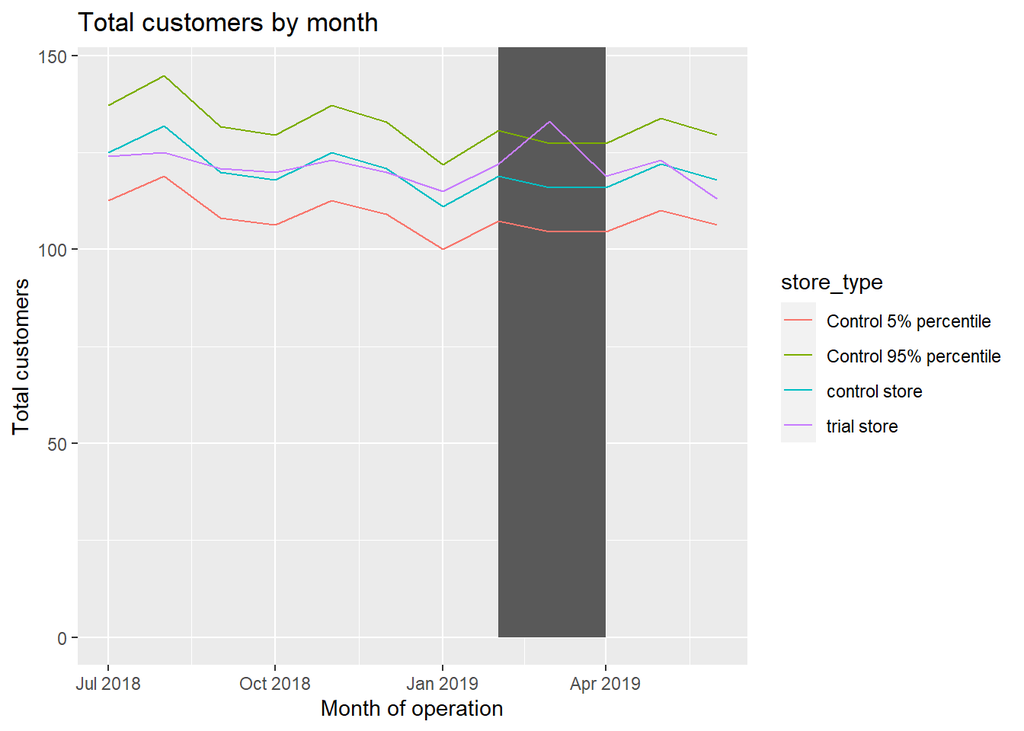

```r
ggplot(trialAssessment_cust88, aes(TransactionMonth, nCustomers, color = store_type)) +
geom_rect(data = trialAssessment_cust88[yearmonth >= 201902 & yearmonth <= 201904 ,],
aes(xmin = min(TransactionMonth), xmax = max(TransactionMonth), ymin = 0 ,
ymax = Inf, color = NULL), show.legend = FALSE) +
geom_line() +
labs(x = "Month of operation", y = "Total customers", title = "Total customers by month")
```

Total number of customers was significantly high in 1/3 of the trial months i.e March

to do:

populate all rows (members of a group) with mean of grouped data**